# Project 0, Part 1: Multilayer Perceptrons

Fashion-MNIST classification with an MLP implemented in PyTorch. The dataset contains 28×28 grayscale images of clothing in 10 classes, 60,000 training and 10,000 test images. Each image is flattened to a 784-dimensional vector before entering the network.

## Task 1: Dataset and baseline model

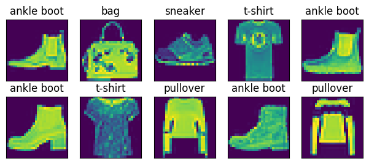

### Baseline architecture

- Input: 784 (28×28 flattened)
- Hidden: 256 units, ReLU
- Output: 10 logits
- Loss: cross-entropy (softmax applied internally)
- Optimizer: SGD, learning rate 0.1
- Batch size: 256, 10 epochs

Total parameters: 784×256 + 256 + 256×10 + 10 = 203,530.

```
Epoch 1: train_loss=0.8595, val_loss=0.7179, val_acc=0.7477
Epoch 2: train_loss=0.5554, val_loss=0.5990, val_acc=0.7869
Epoch 3: train_loss=0.4939, val_loss=0.5095, val_acc=0.8199
Epoch 4: train_loss=0.4602, val_loss=0.4831, val_acc=0.8313
Epoch 5: train_loss=0.4340, val_loss=0.4819, val_acc=0.8289
Epoch 6: train_loss=0.4186, val_loss=0.4460, val_acc=0.8422
Epoch 7: train_loss=0.4043, val_loss=0.4388, val_acc=0.8434
Epoch 8: train_loss=0.3916, val_loss=0.5005, val_acc=0.8245
Epoch 9: train_loss=0.3799, val_loss=0.4145, val_acc=0.8522
Epoch 10: train_loss=0.3718, val_loss=0.4469, val_acc=0.8350
```

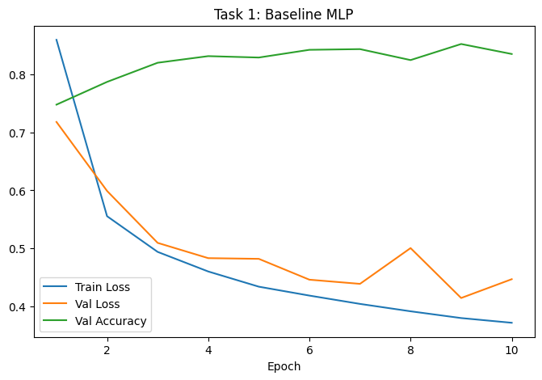

### Results

Final epoch: training loss 0.372, validation loss 0.447, validation accuracy 83.5%. Peak validation accuracy was 85.2% at epoch 9.

## Task 2: Hidden layers and model capacity

Two variations on the baseline: a second hidden layer, and a hidden layer reduced to a single neuron.

```
epoch 1: train 0.8695, val 0.6169, acc 0.7868
epoch 2: train 0.5585, val 0.5651, acc 0.8013
epoch 3: train 0.4994, val 0.4892, acc 0.8299
epoch 4: train 0.4606, val 0.5012, acc 0.8159
epoch 5: train 0.4437, val 0.5557, acc 0.8059
epoch 6: train 0.4193, val 0.5196, acc 0.8169
epoch 7: train 0.4073, val 0.4439, acc 0.8411
epoch 8: train 0.3939, val 0.4206, acc 0.8493
epoch 9: train 0.3810, val 0.4390, acc 0.8379
epoch 10: train 0.3754, val 0.4124, acc 0.8539
```

```
epoch 1: train 1.0254, val 0.6794, acc 0.7507
epoch 2: train 0.5787, val 0.5733, acc 0.7937
epoch 3: train 0.5001, val 0.5218, acc 0.8120
epoch 4: train 0.4582, val 0.5031, acc 0.8202
epoch 5: train 0.4287, val 0.4579, acc 0.8350
epoch 6: train 0.4107, val 0.4287, acc 0.8472
epoch 7: train 0.3913, val 0.4311, acc 0.8456
epoch 8: train 0.3744, val 0.4457, acc 0.8382
epoch 9: train 0.3648, val 0.4293, acc 0.8475
epoch 10: train 0.3534, val 0.6102, acc 0.7815
```

```
epoch 1: train 1.9731, val 1.7932, acc 0.2468
epoch 2: train 1.7475, val 1.7169, acc 0.3086
epoch 3: train 1.6925, val 1.6744, acc 0.2980
epoch 4: train 1.6621, val 1.6512, acc 0.3034
epoch 5: train 1.6424, val 1.6339, acc 0.3176
epoch 6: train 1.6278, val 1.6212, acc 0.3244
epoch 7: train 1.5983, val 1.5552, acc 0.3651
epoch 8: train 1.5286, val 1.5153, acc 0.3616
epoch 9: train 1.5055, val 1.5052, acc 0.3474
epoch 10: train 1.4931, val 1.4910, acc 0.3677
```

### Hidden layer with one neuron (784 → 1 → 10)

Final accuracy 36.8%, with training loss plateauing at 1.49. Random guessing would give 10%, so the model learned something, but it is severely limited.

The cause is an information bottleneck. All 784 pixel values are compressed into a single scalar, and the output layer must separate 10 classes using only that one number. Geometrically, the 10 class regions have to be arranged as intervals along a single line. Any two classes that are not separable by a single threshold on that scalar cannot be distinguished. The failure is structural, not a matter of insufficient training: more epochs cannot recover information the architecture discarded.

### Takeaway

Capacity is a hard floor but not a reliable lever. Too little width makes a task impossible regardless of training. Additional depth, without retuning the learning rate, can make training less stable rather than more accurate.

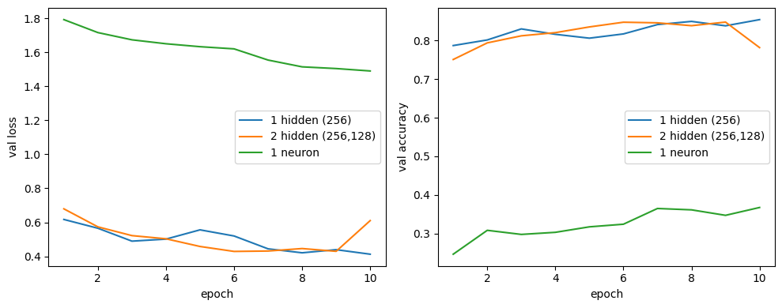

## Task 3: Activation functions and gradients

```
epoch 1: train 1.4591, val 0.9486, acc 0.7123
epoch 2: train 0.8047, val 0.7308, acc 0.7362
epoch 3: train 0.6722, val 0.6606, acc 0.7588
epoch 4: train 0.6114, val 0.6334, acc 0.7599
epoch 5: train 0.5715, val 0.5902, acc 0.7835
epoch 6: train 0.5425, val 0.5581, acc 0.7966
epoch 7: train 0.5212, val 0.5365, acc 0.8091
epoch 8: train 0.5051, val 0.5252, acc 0.8107
epoch 9: train 0.4920, val 0.5122, acc 0.8174
epoch 10: train 0.4820, val 0.5168, acc 0.8090
```

### Sigmoid vs ReLU, single hidden layer

|  | ReLU | Sigmoid |
| --- | --- | --- |
| Epoch 1 train loss | 0.860 | 1.459 |
| Epoch 10 train loss | 0.372 | 0.482 |
| Epoch 10 val accuracy | 83.5% | 80.9% |

Sigmoid starts much worse and converges more slowly, but it is still improving at epoch 10 and would likely narrow the gap with more training. Its curve is also smoother; ReLU's validation loss fluctuates more because its larger effective gradients produce larger parameter updates.

The mechanism is the derivative. Sigmoid's slope has a maximum of 0.25 and is smaller than that for most inputs, so the error signal passing backward through the activation is scaled down by at least a factor of four. ReLU's derivative is exactly 1 wherever the unit is active, so the signal passes through unchanged. With one hidden layer this costs speed; with many layers it becomes fatal, as shown below.

```
layer 1: sigmoid 3.32e-08   relu 1.34e-05
layer 2: sigmoid 1.10e-07   relu 1.06e-05
layer 3: sigmoid 9.35e-07   relu 8.82e-06
layer 4: sigmoid 5.90e-06   relu 9.88e-06
layer 5: sigmoid 4.23e-05   relu 2.00e-05
layer 6: sigmoid 3.16e-04   relu 3.67e-05
layer 7: sigmoid 8.94e-03   relu 4.87e-04
```

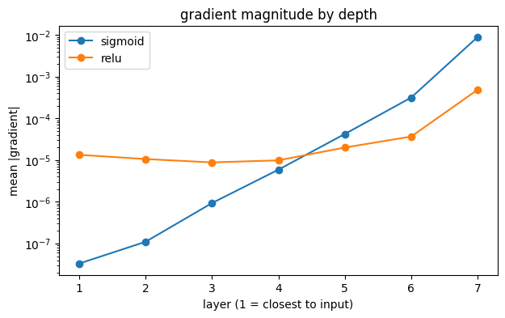

### Vanishing gradients in a deep network

Mean absolute weight gradient per layer, measured after a single backward pass on a 7-layer network (layer 1 is closest to the input):

| Layer | Sigmoid | ReLU |
| --- | --- | --- |
| 1 | 3.32e-08 | 1.34e-05 |
| 2 | 1.10e-07 | 1.06e-05 |
| 3 | 9.35e-07 | 8.82e-06 |
| 4 | 5.90e-06 | 9.88e-06 |
| 5 | 4.23e-05 | 2.00e-05 |
| 6 | 3.16e-04 | 3.67e-05 |
| 7 | 8.94e-03 | 4.87e-04 |

With sigmoid, the gradient shrinks by roughly an order of magnitude per layer moving backward. Layer 7 receives 8.94e-03; layer 1 receives 3.32e-08, a ratio of about 270,000. At a learning rate of 0.1 the first layer's weights move by a negligible amount. Effectively they remain at their random initialization while only the top layers learn.

With ReLU the same span is a factor of roughly 36. Every layer receives a usable signal.

Note that sigmoid's gradients are actually larger than ReLU's at layers 5 through 7. The problem is not magnitude at any single layer but compounding: each backward step through a sigmoid multiplies the signal by that activation's derivative, at most 0.25. Across six layers, 0.25^6 ≈ 2.4e-04. ReLU multiplies by 1 at every active unit, so nothing compounds and the plot on a log scale is nearly flat.

## Task 4: Computational considerations

### Memory during prediction

Inference requires two things in memory:

1. **Parameters** 203,530 floats for the baseline model, about 0.8 MB at float32. This cost is fixed and independent of batch size.
2. **Activations for the current layer only** once the hidden layer's output has been used to compute the logits, those hidden values can be discarded. The same buffer is reused layer by layer.

Inference memory is therefore roughly constant in network depth.

### Memory during training

Training adds several costs on top of the above:

1. **All intermediate activations are retained.** This is the dominant cost. The gradient for a weight is the error signal arriving at its output multiplied by the value that entered it — and that input value is the previous layer's activation. Those activations cannot be freed after the forward pass because the backward pass consumes them. Every layer's output, for every sample in the batch, must persist simultaneously. For one hidden layer at batch size 256 that is 256 × 256 × 4 bytes ≈ 262 KB; the total scales linearly with both batch size and depth.
2. **Gradients** — one float per parameter, doubling parameter memory.
3. **Optimizer state** — none for plain SGD. Adam maintains two running moment estimates per parameter, tripling parameter memory relative to SGD.
4. **The computational graph** — PyTorch records which operations produced which tensors so that `backward()` can traverse the chain in reverse.

### Why training requires more memory than prediction

Inference is a one-directional pass in which intermediate results are disposable: once a value has been consumed by the next layer, it can be overwritten. Training is a round trip. The backward pass needs every value the forward pass produced, so nothing can be released until its gradient has been computed.

The practical consequence is that inference memory is approximately flat in depth while training memory grows linearly with it. This is why a model can often be run on hardware that could not possibly train it. Gradient checkpointing addresses this directly by discarding activations during the forward pass and recomputing them during the backward pass, trading additional compute for reduced peak memory.